# 02_sunset_shadow_speed

## 02_sunset_shadow_speed

#### Question

1. At sunset, the sun’s rays are parallel to the local flat ground. A rocket is launched at an angle of elevation of 0.969 radians above the horizon at a speed of 4150 meters per second. Its shadow is projected onto a tall cliff to the east.

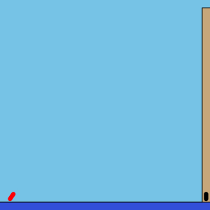

   How fast, in meters per second, is the shadow moving up the cliff? The tolerance is $\pm 10$ m/s.

#### Question

2. At sunset, the sun’s rays are parallel to the local flat ground. A rocket is launched at an angle of elevation of 0.341 radians above the horizon at a speed of 3700 meters per second. Its shadow is projected onto a tall cliff to the east.

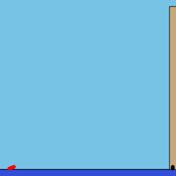

   How fast, in meters per second, is the shadow moving up the cliff? The tolerance is $\pm 10$ m/s.

#### Question

3. At sunset, the sun’s rays are parallel to the local flat ground. A rocket is launched at an angle of elevation of 0.775 radians above the horizon at a speed of 4450 meters per second. Its shadow is projected onto a tall cliff to the east.

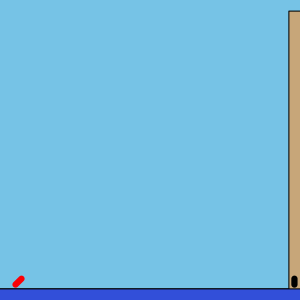

   How fast, in meters per second, is the shadow moving up the cliff? The tolerance is $\pm 10$ m/s.

#### Question

4. At sunset, the sun’s rays are parallel to the local flat ground. A rocket is launched at an angle of elevation of 0.512 radians above the horizon at a speed of 4260 meters per second. Its shadow is projected onto a tall cliff to the east.

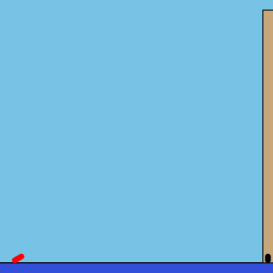

   How fast, in meters per second, is the shadow moving up the cliff? The tolerance is $\pm 10$ m/s.

#### Question

5. At sunset, the sun’s rays are parallel to the local flat ground. A rocket is launched at an angle of elevation of 0.689 radians above the horizon at a speed of 4440 meters per second. Its shadow is projected onto a tall cliff to the east.

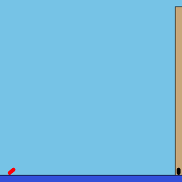

   How fast, in meters per second, is the shadow moving up the cliff? The tolerance is $\pm 10$ m/s.

#### Question

6. At sunset, the sun’s rays are parallel to the local flat ground. A rocket is launched at an angle of elevation of 0.472 radians above the horizon at a speed of 2330 meters per second. Its shadow is projected onto a tall cliff to the east.

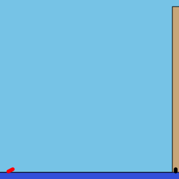

   How fast, in meters per second, is the shadow moving up the cliff? The tolerance is $\pm 10$ m/s.

#### Question

7. At sunset, the sun’s rays are parallel to the local flat ground. A rocket is launched at an angle of elevation of 1.02 radians above the horizon at a speed of 3180 meters per second. Its shadow is projected onto a tall cliff to the east.

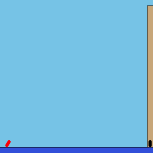

   How fast, in meters per second, is the shadow moving up the cliff? The tolerance is $\pm 10$ m/s.

#### Question

8. At sunset, the sun’s rays are parallel to the local flat ground. A rocket is launched at an angle of elevation of 1.21 radians above the horizon at a speed of 3410 meters per second. Its shadow is projected onto a tall cliff to the east.

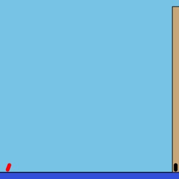

   How fast, in meters per second, is the shadow moving up the cliff? The tolerance is $\pm 10$ m/s.